# Opitimizing Mario Kart 8 Deluxe Gameplay

Félix

2018-02-14

# Introduction

Video games are about learning to make good decisions. I always ejoyed the liberty they offer through the choices available. And this is why I think Zelda : Breath Of the Wild definitly changed something in the open world circle of games. but that’s not the subject today (probably another time though).

Mario Kart was one of my first game I played as a kid. Then on SNES and now on Switch. Back then the was was simple between big and heavy donkey kong or the sneaky Toad, now we get to chose the character, the kart but also its tires and glider (yes, mario kart is also about glidding now).

## Data : type

Each character and item has its own stats that adds up on 5 jauges :

- Speed
- Acceleration
- Weight
- Handling
- Traction

## Data : dimension

44 characters 36 Karts 21 Tires 14 Gliders

## data : source

A quick reddit query I found a dataset (https://docs.google.com/spreadsheets/d/1g7A-38tn9UAIbB2B3sZI-MpILsS3ZS870UTVMRRxh4Q/edit#gid=0) based on in-game experiments filled by Luigi_Fan2’s (https://twitter.com/Luigi_Fan2).

In its annotations, we can see that there are many redundancies in the karts and parts :

|—————————————————————-| | Characters | |—————————————————————-| | Baby Peach = Baby Daisy | | Baby Rosalina = Lemmy | | Baby Mario = Baby Luigi = Dry Bones = Light Mii | | Toadette = Wendy = Isabelle | | Koopa Troopa = Lakitu = Bowser Jr. | | Toad = Shy Guy = Larry | | Cat Peach = Inkling Girl = Female Villager | | Peach = Daisy = Yoshi | | Tanooki Mario = Inkling Boy = Male Villager | | Mario = Ludwig = Medium Mii | | Luigi = Iggy | | Rosalina = King Boo = Link | | Metal Mario = Gold Mario = Pink Gold Peach | | Waluigi = Donkey Kong = Roy | | Wario = Dry Bowser | | Bowser = Morton = Heavy Mii | | Koopa Troopa = Lakitu = Bowser Jr. |

|—————————————————————-| | Karts | |—————————————————————-| | Standard Kart = 300 SL Roadster = The Duke | | Pipe Frame = Varmint = City Tripper | | Mach 8 = Sports Coupe = Inkstriker | | Steel Driver = Tri-Speeder = Bone Rattler | | Cat Cruiser = Comet = Yoshi Bike = Teddy Buggy | | Circuit Special = B-Dasher = P-Wing | | Badwagon = GLA = Standard ATV | | Prancer = Sport Bike = Jet Bike | | Biddybuggy = Mr Scooty | | Landship = Streetle | | Sneeker = Gold Standard = Master Cycle | | W 25 Silver Arrow = Standard Bike = Flame Rider = Wild Wiggler | | Blue Falcon = Splat Buggy | | Tanooki Kart = Koopa Clown |

|—————————————————————-| | Tires | |—————————————————————-|  
| Standard = Blue Standard = GLA Tires | | Monster = Hot Monster | | Roller = Azure Roller | | Slim = Wood = Crimson Slim | | Slick = Cyber Slick | | Metal = Gold Tires | | Button = Leaf Tires | | Off-Road = Retro Off-Road = Triforce Tires | | Sponge = Cushion |

|—————————————————————-| | Glidders | |—————————————————————-| | Super Glider = Waddle Wing = Hylian Kite | | Cloud Glider = Parachute = Flower Glider = Paper Glider | | Wario Wing = Plane Glider = Gold Glider | | Peach Parasol = Parafoil = Bowser Kite = MKTV Parafoil |

So refer to this table if you want equivalent stats but different skins.

Instead of directly importing data from google drive, I built an excel file

# Import data

```r
library(readxl)
Char<- read_xlsx("Mario Kart 8 Deluxe Stat.xlsx",sheet = "Char",col_names = T, col_types = c("text",rep("numeric", 12)))

Kart <- read_xlsx("Mario Kart 8 Deluxe Stat.xlsx",sheet = "Kart",col_names = T, col_types = c("text",rep("numeric", 12)))

Tire <- read_xlsx("Mario Kart 8 Deluxe Stat.xlsx",sheet = "Tire",col_names = T, col_types = c("text",rep("numeric", 12)))

Glide <- read_xlsx("Mario Kart 8 Deluxe Stat.xlsx",sheet = "Glide",col_names = T, col_types = c("text",rep("numeric", 12)))


library(tidyverse)
Char<-Char %>% add_column(Type="Char", .after='ID')
Kart <- Kart %>% add_column(Type="Kart", .after='ID')
Tire <- Tire %>% add_column(Type="Tire", .after='ID')
Glide <- Glide %>% add_column(Type="Glide", .after='ID')

data <-  full_join(Char, Kart) %>% full_join(Glide) %>% full_join(Tire)
```

# compute mean speed and handling

```r
data <- data %>%mutate(Speed_mean=rowMeans(data[grepl("Speed", names(data))])) %>% mutate(Handling_mean=rowMeans(data[grepl("Handling", names(data))]))
```

```r
library(qtlcharts)
iplotCorr(data %>% filter(Type=="Char") %>% select(-ID, -Type, -Speed_Land:-Speed_Gliding,-Handling_Land:-Handling_Gliding))
```

```
## Set screen size to height=700 x width=1000
```

[interactive chart not shown]

# How characters are distributed between Acceleration and Speed

[figure not shown]

```r
ggplot(data %>% filter(Type=="Char"), aes(x=Speed_mean,y=Accel))+geom_point(aes(size=Weight, fill=`M-turbo`), pch=21)+ggrepel::geom_text_repel(aes(label=ID), min.segment.length = 0.1,point.padding = unit(1.2, 'lines'),box.padding = unit(0.6, 'lines'), force=2)+viridis::scale_fill_viridis()
```

Fastest characters are also the heaviest and the ones with lowest acceleration, handling and Mini-turbo

# Wich Kart provide the best bonus Speed/Accelaration ?

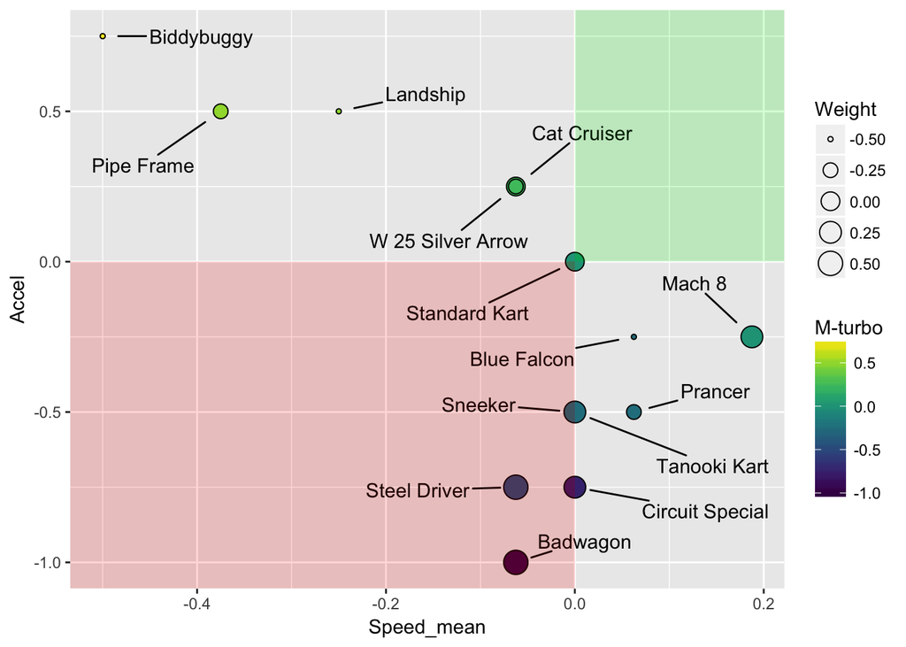

```r
ggplot(data %>% filter(Type=="Kart"), aes(x=Speed_mean,y=Accel))+geom_point(aes(size=Weight, fill=`M-turbo`), pch=21)+ggrepel::geom_text_repel(aes(label=ID), min.segment.length = 0.1,point.padding = unit(1.2, 'lines'),box.padding = unit(0.6, 'lines'), force=2)+viridis::scale_fill_viridis()+geom_rect(aes(ymin=-Inf, ymax=0, xmin=-Inf, xmax=0), alpha=0.01, fill="red")+geom_rect(aes(ymin=0, ymax=Inf, xmin=0, xmax=Inf), alpha=0.01, fill="green")
```

**A Speed/acceleration Bonus Ratio would be good to condensate information**

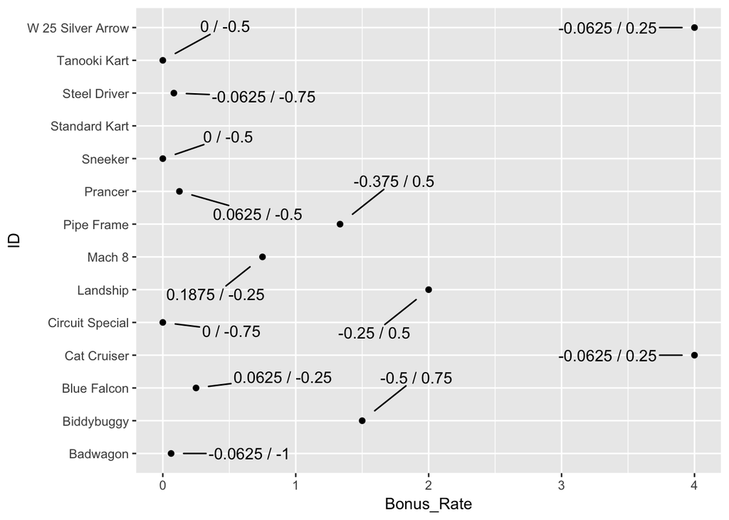

```r
data <- data %>% mutate("Bonus_Rate"=ifelse(Speed_mean > Accel, abs(Speed_mean/Accel),abs(Accel/Speed_mean)))

ggplot(data %>% filter(Type=="Kart"), aes(Bonus_Rate, ID))+geom_point()+ggrepel::geom_text_repel(aes(label=paste(Speed_mean,"/",Accel)), min.segment.length = 0.1,point.padding = unit(1.2, 'lines'),box.padding = unit(0.6, 'lines'), force=2)
```

W 25 Silver Arrow and Cat Cruiser provides the most bonus regarding to malus (4 times more bonus than malus)

```r
data$total <- rowSums(data[,c(7,8,13:17)], na.rm = T)

data %>%group_by(Type) %>%filter(total==max(total, na.rm=T))
```

```
## # A tibble: 4 x 18
## # Groups:   Type [4]
##   ID       Type  Speed_Land `Speed_Anti-G` Speed_Water Speed_Gliding Accel
##   <chr>    <chr>      <dbl>          <dbl>       <dbl>         <dbl> <dbl>
## 1 Baby Pe… Char       2.25           2.00        2.50          2.75  4.00
## 2 W 25 Si… Kart      -0.250          0.250      -0.250         0.    0.250
## 3 Cloud G… Glide     -0.250          0.250       0.           -0.250 0.250
## 4 Roller   Tire      -0.500         -0.500       0.            0.    0.500
## # ... with 11 more variables: Weight <dbl>, Handling_Land <dbl>,
## #   `Handling_Anti-G` <dbl>, Handling_Water <dbl>, Handling_Gliding <dbl>,
## #   Traction <dbl>, `M-turbo` <dbl>, Speed_mean <dbl>,
## #   Handling_mean <dbl>, Bonus_Rate <dbl>, total <dbl>
```

Which Char-Kart-Tire-Glide is the best combination to maximize performance ? The parameters that need to be optimized are :

-Speed -Acceleration -Handling -Turbo

Weight is mostly players preference depending on the kind of gameplay, as seen before : -High wheight have best speed. Fits players that can dodge most enemy items, don’t want to be pushed and are sure to stay on the tracks. -Low Wheight have best acceleration. Fits players that want return to max speed faster after getting ruined by a blue shell and are able to dodge the big ones.

Note that lighter characters have Higher Handling (better turns) and better Turbo (takes less time to trigger and last longer). This is why I prefer Medium-Light characters: even if Turbo are not super-fast, I can trigger turbo more often and commit few errors (*who doesn’t ?*) without being severly punished.

## Generation of all combinations

```r
#method1
library(gtools)

comb <- as_data_frame(permutations(n=length(data$ID),r=4,v=data$ID, repeats.allowed = F)) %>% filter(V1 %in% Char$ID & V2 %in% Kart$ID & V3 %in% Tire$ID & V4 %in% Glide$ID)

names(comb)[1] <- "ID"
comb1 <- inner_join(comb, data, by="ID")

names(comb)[1] <- "V1"
names(comb)[2] <- "ID"
comb2 <- inner_join(comb, data, by="ID")

names(comb)[2] <- "V2"
names(comb)[3] <- "ID"
comb3 <- inner_join(comb, data, by="ID")

names(comb)[3] <- "V3"
names(comb)[4] <- "ID"
comb4 <- inner_join(comb, data, by="ID")

data_combo <- comb1[,6:21]+comb2[,6:21]+comb3[,6:21]+comb4[,6:21]

data_combo <- cbind(comb[,1:4], data_combo)

# Rename a column in R
data_combo <- comb1[,6:20]+comb2[,6:20]+comb3[,6:20]+comb4[,6:20]

data_combo <- cbind(comb[,1:4], data_combo)

names(data_combo)[1]<-"Char"
names(data_combo)[2]<-"Kart"
names(data_combo)[3]<-"Tire"
names(data_combo)[4]<-"Glidder"

data_combo$ID <- seq_len(nrow(data_combo))
```

```r
#method 2 (not working)
data_combo <- as.data.frame((data %>% group_by(Type) %>% sample_n(1) %>% ungroup() %>% mutate_if(is.numeric,sum) %>% ungroup() %>% mutate(ID=paste(ID, collapse=" + ")) %>% select(-Type)%>%unique()))

test <- replicate(5, { rbind(data_combo, (data %>% group_by(Type) %>% sample_n(1) %>% ungroup() %>% mutate_if(is.numeric,sum) %>% ungroup() %>% mutate(ID=paste(ID, collapse=" + ")) %>% select(-Type)%>%unique()))} )
```

```r
data_combo  <- data_combo  %>%mutate(Speed_mean=rowMeans(data_combo [grepl("Speed", names(data_combo ))])) %>% mutate(Handling_mean=rowMeans(data_combo [grepl("Handling", names(data_combo ))]))

data_combo$total <- rowSums(data_combo[,c(9,15:18)], na.rm = T)

data_combo$total_A_S <- rowSums(data_combo[,c(9,17)])

data_combo <- data_combo %>% mutate(A_SRatio= `Accel`/Speed_mean)
```

```r
library(skimr)
skim(data_combo)
```

```
## Skim summary statistics
##  n obs: 8064
##  n variables: 23
##
## Variable type: character
##  variable missing complete    n min max empty n_unique
##      Char       0     8064 8064   4  13     0       16
##   Glidder       0     8064 8064  10  13     0        4
##      Kart       0     8064 8064   6  17     0       14
##      Tire       0     8064 8064   4   8     0        9
##
## Variable type: integer
##  variable missing complete    n   mean      sd p0     p25 median     p75
##        ID       0     8064 8064 4032.5 2328.02  1 2016.75 4032.5 6048.25
##  p100     hist
##  8064 ▇▇▇▇▇▇▇▇
##
## Variable type: numeric
##          variable missing complete    n  mean   sd    p0   p25 median
##          A_SRatio       0     8064 8064  1.12 0.52  0.21  0.73   1.02
##             Accel       0     8064 8064  3.4  0.83  1     2.75   3.5
##        Bonus_Rate    4736     3328 8064  5.96 1.87  3.03  4.61   5.67
##   Handling_Anti-G       0     8064 8064  3.53 0.84  1     3      3.5
##  Handling_Gliding       0     8064 8064  3.5  0.85  1     3      3.5
##     Handling_Land       0     8064 8064  3.61 0.85  1     3      3.75
##     Handling_mean       0     8064 8064  3.52 0.8   1.19  2.94   3.56
##    Handling_Water       0     8064 8064  3.43 0.85  1     2.75   3.5
##           M-turbo       0     8064 8064  3.35 0.8   1     2.75   3.25
##      Speed_Anti-G       0     8064 8064  3.37 0.93  0.75  2.75   3.25
##     Speed_Gliding       0     8064 8064  3.43 0.92  1     2.75   3.5
##        Speed_Land       0     8064 8064  3.36 0.96  0.75  2.75   3.25
##        Speed_mean       0     8064 8064  3.37 0.84  1.5   2.69   3.38
##       Speed_Water       0     8064 8064  3.33 0.92  1     2.5    3.25
##             total       0     8064 8064 16.95 2.17 10    15.44  17.06
##         total_A_S       0     8064 8064  6.78 0.73  4.31  6.31   6.81
##          Traction       0     8064 8064  3.31 0.84  0.75  2.75   3.25
##            Weight       0     8064 8064  3.18 0.98  0.75  2.5    3.25
##    p75  p100     hist
##   1.42  3.83 ▅▇▆▂▁▁▁▁
##   4     5.75 ▁▂▇▇▇▇▂▁
##   7.19 11.79 ▆▅▇▅▃▂▁▁
##   4.25  5.75 ▁▁▆▆▆▇▂▁
##   4     5.75 ▁▂▆▆▇▇▂▁
##   4.25  5.75 ▁▁▅▆▆▇▃▁
##   4.12  5.62 ▁▂▅▇▇▆▃▁
##   4     5.75 ▁▂▇▇▇▇▂▁
##   4     5.75 ▁▂▇▇▇▇▂▁
##   4     5.75 ▁▂▅▇▆▆▂▁
##   4.25  5.75 ▁▂▇▆▆▇▃▁
##   4     5.75 ▁▃▅▇▅▆▂▁
##   4.06  5.12 ▁▆▇▇▇▆▆▃
##   4     5.75 ▁▃▇▆▆▇▂▁
##  18.56 22.69 ▁▁▃▆▇▇▃▁
##   7.31  8.56 ▁▁▃▆▇▇▃▁
##   4     5.75 ▁▂▃▇▆▆▁▁
##   4     5.75 ▁▃▅▇▅▆▂▁
```

```r
data_combo %>% filter(Speed_mean > 3 & Accel > 3) %>% top_n(10,A_SRatio)  %>% arrange(desc(A_SRatio))
```

```
##             Char              Kart     Tire       Glidder Speed_Land
## 1          Luigi        Biddybuggy   Roller  Cloud Glider       2.25
## 2          Mario        Biddybuggy   Roller  Cloud Glider       2.25
## 3          Peach          Landship   Roller  Cloud Glider       2.25
## 4  Tanooki Mario          Landship   Roller  Cloud Glider       2.25
## 5      Cat Peach       Cat Cruiser   Button  Cloud Glider       2.50
## 6      Cat Peach       Cat Cruiser   Roller  Super Glider       2.50
## 7      Cat Peach       Cat Cruiser   Roller    Wario Wing       2.50
## 8      Cat Peach          Landship Standard  Cloud Glider       2.50
## 9      Cat Peach     Standard Kart   Roller  Cloud Glider       2.50
## 10     Cat Peach W 25 Silver Arrow   Button  Cloud Glider       2.50
## 11     Cat Peach W 25 Silver Arrow   Roller  Super Glider       2.50
## 12     Cat Peach W 25 Silver Arrow   Roller    Wario Wing       2.50
## 13         Luigi        Biddybuggy   Button Peach Parasol       2.50
## 14         Mario        Biddybuggy   Button Peach Parasol       2.50
```

[output cut: 61 more lines]

## Additional stats

```r
#Land Speed and Handling are weighted (twice more important) for mean calculation since most part of the races happens on regular soil.

data_combo  <- data_combo %>% rowwise() %>% mutate(Speed_mean=weighted.mean(x=c(Speed_Land,`Speed_Anti-G`, Speed_Water, Speed_Gliding), w=c(2,2,1,1))) %>% rowwise() %>%mutate(Handling_mean=weighted.mean(x=c(Handling_Land,`Handling_Anti-G`, Handling_Water, Handling_Gliding), w=c(2,2,1,1)))

data_combo <- data_combo %>% mutate(w_cat = cut(Weight,breaks = c(0,2,3,4,5,6),labels = c("Super Light","Light","Medium","Heavy", "Super Heavy")))#Create Weigh categories

data_combo <- data_combo %>% mutate(total_perf=as.numeric(Accel+Speed_mean+Handling_mean+Traction+`M-turbo`)) #Weigh is not included in the total_perf computing.

data_combo <- data_combo %>% select(ID, Char:Glidder, total_perf, Speed_mean, Speed_Land:Weight,w_cat, Handling_mean,Handling_Land:Bonus_Rate) %>% ungroup()
```

## Summary of data

```r
library(skimr)
library(ggridges)
skim(data_combo)
```

```
## Skim summary statistics
##  n obs: 8064
##  n variables: 22
##
## Variable type: character
##  variable missing complete    n min max empty n_unique
##      Char       0     8064 8064   4  13     0       16
##   Glidder       0     8064 8064  10  13     0        4
##      Kart       0     8064 8064   6  17     0       14
##      Tire       0     8064 8064   4   8     0        9
##
## Variable type: factor
##  variable missing complete    n n_unique
##     w_cat       0     8064 8064        5
##                                  top_counts ordered
##  Lig: 2761, Med: 2549, Hea: 1381, Sup: 1223   FALSE
##
## Variable type: integer
##  variable missing complete    n   mean      sd p0     p25 median     p75
##        ID       0     8064 8064 4032.5 2328.02  1 2016.75 4032.5 6048.25
##  p100     hist
##  8064 ▇▇▇▇▇▇▇▇
##
## Variable type: numeric
##          variable missing complete    n  mean   sd    p0   p25 median
##             Accel       0     8064 8064  3.4  0.83  1     2.75   3.5
##        Bonus_Rate    4736     3328 8064  5.96 1.87  3.03  4.61   5.67
##   Handling_Anti-G       0     8064 8064  3.53 0.84  1     3      3.5
##  Handling_Gliding       0     8064 8064  3.5  0.85  1     3      3.5
##     Handling_Land       0     8064 8064  3.61 0.85  1     3      3.75
##     Handling_mean       0     8064 8064  3.54 0.81  1.12  2.96   3.54
##    Handling_Water       0     8064 8064  3.43 0.85  1     2.75   3.5
##           M-turbo       0     8064 8064  3.35 0.8   1     2.75   3.25
##      Speed_Anti-G       0     8064 8064  3.37 0.93  0.75  2.75   3.25
##     Speed_Gliding       0     8064 8064  3.43 0.92  1     2.75   3.5
##        Speed_Land       0     8064 8064  3.36 0.96  0.75  2.75   3.25
##        Speed_mean       0     8064 8064  3.37 0.86  1.38  2.67   3.38
##       Speed_Water       0     8064 8064  3.33 0.92  1     2.5    3.25
##        total_perf       0     8064 8064 16.97 2.1  10.38 15.54  17.04
##          Traction       0     8064 8064  3.31 0.84  0.75  2.75   3.25
##            Weight       0     8064 8064  3.18 0.98  0.75  2.5    3.25
##    p75  p100     hist
##   4     5.75 ▁▂▇▇▇▇▂▁
##   7.19 11.79 ▆▅▇▅▃▂▁▁
##   4.25  5.75 ▁▁▆▆▆▇▂▁
##   4     5.75 ▁▂▆▆▇▇▂▁
##   4.25  5.75 ▁▁▅▆▆▇▃▁
##   4.12  5.67 ▁▂▅▇▇▆▃▁
##   4     5.75 ▁▂▇▇▇▇▂▁
##   4     5.75 ▁▂▇▇▇▇▂▁
##   4     5.75 ▁▂▅▇▆▆▂▁
##   4.25  5.75 ▁▂▇▆▆▇▃▁
##   4     5.75 ▁▃▅▇▅▆▂▁
##   4.04  5.21 ▁▅▇▇▇▇▆▂
##   4     5.75 ▁▃▇▆▆▇▂▁
##  18.5  22.58 ▁▁▃▆▇▆▃▁
##   4     5.75 ▁▂▃▇▆▆▁▁
##   4     5.75 ▁▃▅▇▅▆▂▁
```

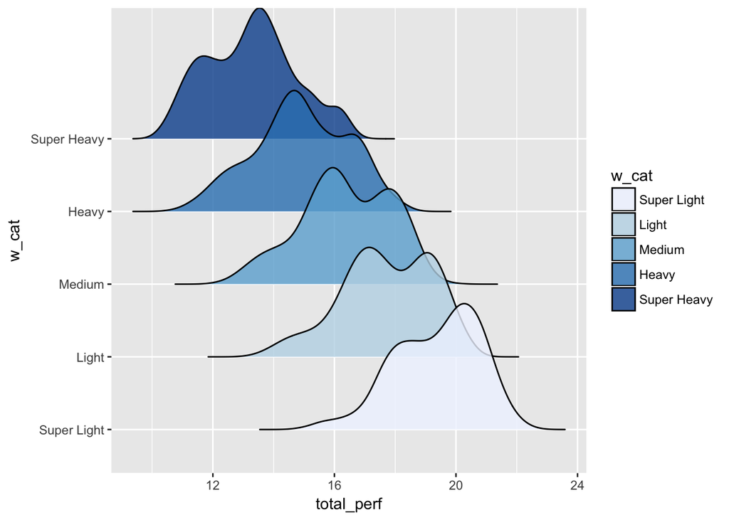

```r
ggplot(data_combo, aes(total_perf, w_cat))+geom_density_ridges(aes(fill=w_cat),panel_scaling = F, alpha=0.8,rel_min_height = 0.000001)+scale_fill_brewer()
```

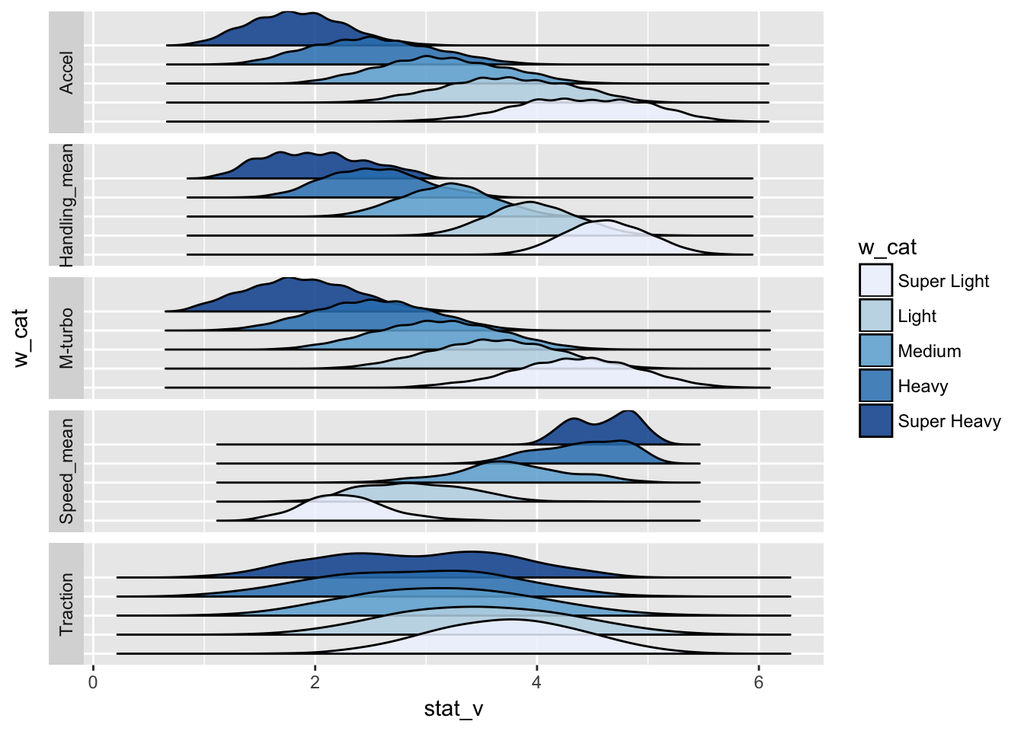

```r
ggplot(data_combo %>% gather(key=stat, value=stat_v, c(Accel, Speed_mean, `M-turbo`,Traction, Handling_mean))) + geom_density_ridges2(aes(stat_v, w_cat, fill=w_cat), alpha=0.85)+facet_grid(stat~., switch = "y")+scale_fill_brewer()+theme(axis.ticks.y = element_blank(), axis.text.y = element_blank())
```

```r
data_combo %>% group_by(w_cat) %>% select(-Char,-Glidder, -Kart, -Tire) %>% select(Accel, Speed_mean, Handling_mean, `M-turbo`,Traction)%>% skim_to_wide() %>% arrange(variable)
```

```
## # A tibble: 25 x 14
##    type   w_cat   variable  missing complete n     mean  sd    p0    p25
##    <chr>  <fct>   <chr>     <chr>   <chr>    <chr> <chr> <chr> <chr> <chr>
##  1 numer… Super … Accel     0       1223     1223  "4.4… 0.58  2.75  "4  …
##  2 numer… Light   Accel     0       2761     2761  3.73  0.55  "2  … 3.25
##  3 numer… Medium  Accel     0       2549     2549  3.14  0.53  1.75  2.75
##  4 numer… Heavy   Accel     0       1381     1381  2.52  0.53  1.25  2.25
##  5 numer… Super … Accel     0       150      150   1.84  0.41  "1  … "1.5…
##  6 numer… Super … Handling… 0       1223     1223  4.63  0.36  3.58  4.38
##  7 numer… Light   Handling… 0       2761     2761  3.96  0.39  2.79  3.71
##  8 numer… Medium  Handling… 0       2549     2549  3.19  0.39  2.08  2.92
##  9 numer… Heavy   Handling… 0       1381     1381  2.53  0.42  1.38  2.21
## 10 numer… Super … Handling… 0       150      150   2.01  0.45  1.12  1.67
## # ... with 15 more rows, and 4 more variables: median <chr>, p75 <chr>,
## #   p100 <chr>, hist <chr>
```

Lighest combo have higher totals once weight is put out of the balance.

# Wich is the Most balanced Combo ?

Is there any combination that results with all stats being above or equal to 3.5 ?

```r
data_combo %>%filter(Speed_Land>=3.5 & Accel >= 3.5 & Handling_Land >=3.5 & `M-turbo` >=3.5 & Traction >=3.5) %>% select(Char, Kart, Tire, Glidder,total_perf,Weight, Accel, Speed_mean,Speed_Land, Handling_mean, `M-turbo`,Traction, Handling_Land)
```

```
## # A tibble: 48 x 13
##    Char  Kart  Tire  Glidder total_perf Weight Accel Speed_mean Speed_Land
##    <chr> <chr> <chr> <chr>        <dbl>  <dbl> <dbl>      <dbl>      <dbl>
##  1 Luigi Mach… Stan… Cloud …       18.1   3.50  3.50       3.96       3.50
##  2 Luigi Stan… Spon… Super …       17.6   3.25  3.50       3.58       3.50
##  3 Luigi W 25… Stan… Super …       18.6   3.25  3.75       3.75       3.50
##  4 Luigi W 25… Stan… Wario …       18.4   3.50  3.75       3.79       3.50
##  5 Mario Cat … Stan… Super …       18.0   3.50  3.75       3.71       3.50
##  6 Mario Stan… Stan… Cloud …       18.0   3.25  3.75       3.75       3.50
##  7 Mario W 25… Stan… Super …       18.6   3.25  3.75       3.75       3.50
##  8 Mario W 25… Stan… Wario …       18.4   3.50  3.75       3.79       3.50
##  9 Meta… Bidd… Stan… Super …       18.7   4.00  4.00       3.79       3.50
## 10 Meta… Land… Butt… Super …       18.6   3.50  4.00       3.75       3.50
## # ... with 38 more rows, and 4 more variables: Handling_mean <dbl>,
## #   `M-turbo` <dbl>, Traction <dbl>, Handling_Land <dbl>
```

I want a Weight less than 3.5 and the best Accel I can get in this list.

```r
data_combo %>%filter(Speed_Land>=3.5 & Accel >= 3.5 & Handling_Land >=3.5 & `M-turbo` >=3.5 & Traction >=3.5 & Weight <3.5)%>% top_n(n=5, wt=Accel) %>% select(Char, Kart, Tire, Glidder,total_perf,Weight, Accel, Speed_mean,Speed_Land, Handling_mean, `M-turbo`,Traction, Handling_Land) %>% arrange(desc(total_perf))
```

```
## # A tibble: 13 x 13
##    Char  Kart  Tire  Glidder total_perf Weight Accel Speed_mean Speed_Land
##    <chr> <chr> <chr> <chr>        <dbl>  <dbl> <dbl>      <dbl>      <dbl>
##  1 Rosa… W 25… Stan… Cloud …       19.1   3.25  3.75       3.96       3.50
##  2 Walu… Land… Roll… Super …       19.1   3.00  4.25       3.83       3.50
##  3 Rosa… Land… Stan… Super …       19.0   3.25  3.75       3.67       3.50
##  4 Rosa… W 25… Butt… Super …       18.8   3.00  3.75       3.83       3.50
##  5 Luigi W 25… Stan… Super …       18.6   3.25  3.75       3.75       3.50
##  6 Mario W 25… Stan… Super …       18.6   3.25  3.75       3.75       3.50
##  7 Rosa… W 25… Butt… Wario …       18.5   3.25  3.75       3.88       3.50
##  8 Peach Blue… Stan… Cloud …       18.4   2.25  3.75       3.62       3.50
##  9 Rosa… Stan… Roll… Super …       18.4   3.25  3.75       3.71       3.50
## 10 Peach Stan… Stan… Super …       18.2   3.00  3.75       3.54       3.50
## 11 Peach Blue… Stan… Peach …       18.0   2.50  3.75       3.58       3.50
## 12 Mario Stan… Stan… Cloud …       18.0   3.25  3.75       3.75       3.50
## 13 Peach Stan… Stan… Wario …       18.0   3.25  3.75       3.58       3.50
## # ... with 4 more variables: Handling_mean <dbl>, `M-turbo` <dbl>,
## #   Traction <dbl>, Handling_Land <dbl>
```

## Best overall combination ?

[figure not shown]

```r
ggplot(data_combo, aes(Speed_mean, Accel))+
  geom_point(pch=21, alpha=0.95, aes(fill=`M-turbo`, size=Handling_mean))+
  viridis::scale_fill_viridis(direction=1)+
  geom_abline(intercept=0, slope=1,size=1.5)+
  geom_vline(xintercept=4)+
  geom_hline(yintercept=4)+
  ggrepel::geom_label_repel(data=(data_combo %>% filter(Speed_mean >= 4 & Accel >= 4)%>% top_n(3,total_perf)), aes(x=Speed_mean, y=Accel,label=paste(round(total_perf,2),round(Speed_mean,2), round(Accel,2),"\n",Char,"+",Kart,"+", Tire,"+", Glidder)), size=2.6, segment.colour = "black",force=9,point.padding = unit(0.5, "lines"), box.padding = 0, color="black", fill="white", alpha=0.85, segment.size = 1, nudge_y = 0.5)
```

# Comparative Chart of top_n

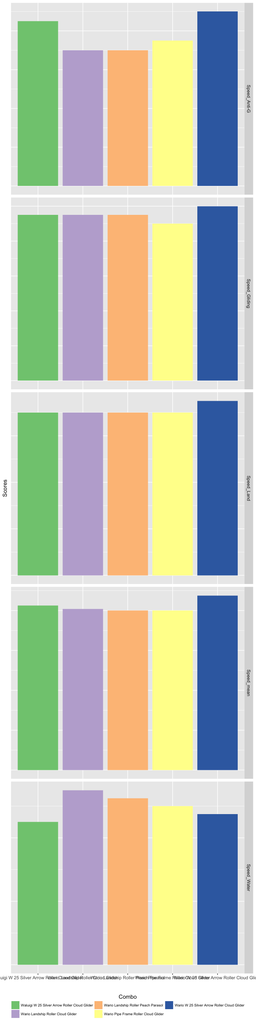

```r
Best_Over_Combo <-  data_combo %>% filter(Speed_mean >= 4 & Accel >= 4)%>% top_n(5,total_perf) %>% select(ID, Char, Kart, Tire, Glidder)

ggplot(gather((data_combo %>% filter(ID %in% Best_Over_Combo$ID)),key = Stat, value=Stat_v, c(Speed_mean,Speed_Land:Speed_Gliding)),aes(paste(Char, Kart,Tire,Glidder), Stat_v))+geom_col(aes(fill=paste(Char, Kart,Tire,Glidder)))+facet_grid(Stat~., scales = "free")+theme(axis.text.y = element_blank(), legend.position = "bottom", legend.text = element_text(size=7), axis.ticks.y = element_blank(), legend.direction = "vertical", legend.title.align = 0.5)+guides(fill=guide_legend(ncol=3))+labs(fill="Combo", x="", y="Scores")+scale_fill_brewer(type = "qual")
```

problem here is that Speed_Land is low. Speen_mean was compensated by the High Speed_Water

[figure not shown]

```r
ggplot(gather(data_combo %>% filter(Accel>=4 & Speed_mean>5& Handling_mean>4) %>% top_n(1, total_perf),key = Stat, value=Stat_v, c(Speed_Land:Speed_Gliding,Accel, Weight, Handling_Land:Handling_Gliding, Traction, `M-turbo`)),aes(Stat, Stat_v))+geom_col()+coord_flip()
```

# Best combinations for Yoshi

```r
data_combo %>%filter(Char=="Peach", Speed_Land >3) %>% select(Char, Kart, Tire, Glidder,total_perf,Weight, Accel, Speed_mean,Speed_Land, Handling_mean, `M-turbo`,Traction, Handling_Land) %>% arrange(desc(total_perf)) %>% top_n(10, Accel)
```

```
## # A tibble: 20 x 13
##    Char  Kart  Tire  Glidder total_perf Weight Accel Speed_mean Speed_Land
##    <chr> <chr> <chr> <chr>        <dbl>  <dbl> <dbl>      <dbl>      <dbl>
##  1 Peach W 25… Stan… Super …       19.4   2.75    4.       3.50       3.25
##  2 Peach W 25… Stan… Wario …       19.1   3.00    4.       3.54       3.25
##  3 Peach W 25… Off-… Cloud …       19.0   2.75    4.       3.50       3.25
##  4 Peach Land… Off-… Super …       18.8   2.75    4.       3.21       3.25
##  5 Peach Blue… Roll… Super …       18.8   2.00    4.       3.33       3.25
##  6 Peach Cat … Stan… Super …       18.8   3.00    4.       3.46       3.25
##  7 Peach Stan… Stan… Cloud …       18.7   2.75    4.       3.50       3.25
##  8 Peach W 25… Off-… Peach …       18.7   3.00    4.       3.46       3.25
##  9 Peach Land… Off-… Wario …       18.6   3.00    4.       3.25       3.25
## 10 Peach Blue… Roll… Wario …       18.5   2.25    4.       3.38       3.25
## 11 Peach Blue… Butt… Cloud …       18.5   1.75    4.       3.46       3.25
## 12 Peach Cat … Stan… Wario …       18.5   3.25    4.       3.50       3.25
## 13 Peach Pipe… Off-… Super …       18.5   3.00    4.       3.17       3.25
## 14 Peach Cat … Off-… Cloud …       18.4   3.00    4.       3.46       3.25
## 15 Peach Stan… Stan… Peach …       18.4   3.00    4.       3.46       3.25
## 16 Peach Stan… Butt… Super …       18.3   2.50    4.       3.38       3.25
## 17 Peach Pipe… Off-… Wario …       18.2   3.25    4.       3.21       3.25
## 18 Peach Blue… Butt… Peach …       18.2   2.00    4.       3.42       3.25
## 19 Peach Stan… Butt… Wario …       18.1   2.75    4.       3.42       3.25
## 20 Peach Cat … Off-… Peach …       18.0   3.25    4.       3.42       3.25
## # ... with 4 more variables: Handling_mean <dbl>, `M-turbo` <dbl>,
## #   Traction <dbl>, Handling_Land <dbl>
```

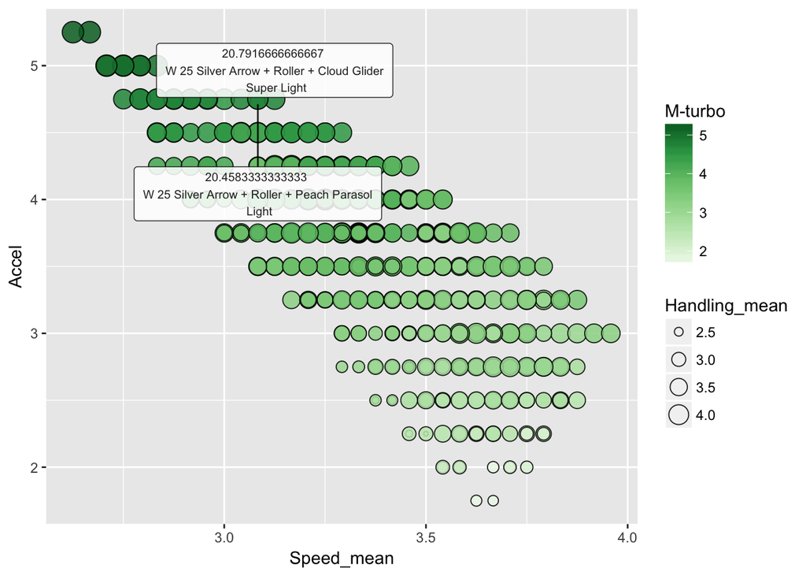

```r
ggplot(data_combo %>%filter(Char=="Peach"), aes(Speed_mean, Accel))+
  geom_point(pch=21, alpha=0.85, aes(fill=`M-turbo`, size=Handling_mean))+
  ggrepel::geom_label_repel(data=(data_combo %>%filter(Char=="Peach", Speed_mean >= 3 & Accel >= 3) %>% top_n(2, total_perf)), aes(x=Speed_mean, y=Accel,label=paste(total_perf,"\n",Kart,"+", Tire,"+", Glidder,"\n", w_cat)), size=2.6, segment.colour = "black",force=5,point.padding = unit(0.5, "lines"), box.padding = 1.5, color="black", fill="white", alpha=0.87, direction = "y")+
  scale_fill_distiller(direction=1, palette="Greens")
```